# DATA 621 Final Project

Group 2

### Overview

There are millions of stray pets around the world, some of which are fortunate enough to be adopted while many others are not. While adoption of a pet is often the definition of success, the rate at which a pet is adopted is also a key success factor - pets that take a long time to adopt contribute to over-crowded animal shelters and can prevent taking on new strays. Sadly, pets that are not adopted eventually need to be euthanized.

### Learn more about the data

[About the data](https://www.kaggle.com/c/petfinder-adoption-prediction/data)

### What to Predict

Predictor (Adoption Speed) Description: Predict how quickly, if at all, a pet is adopted.

The values are determined in the following way: 0 - Pet was adopted on the same day as it was listed. 1 - Pet was adopted between 1 and 7 days (1st week) after being listed. 2 - Pet was adopted between 8 and 30 days (1st month) after being listed. 3 - Pet was adopted between 31 and 90 days (2nd & 3rd month) after being listed. 4 - No adoption after 100 days of being listed.

### This notebook…

inputs the transformation training data and completes an analysis of the features, with visuals.

```r
knitr::opts_chunk$set(echo = TRUE)
knitr::opts_chunk$set(message = FALSE)
knitr::opts_chunk$set(warning = FALSE)
```

```r
library(dplyr)
library(reshape)
library(ggplot2)
library(purrr)
library(psych)
library(tidyr)
library(corrplot)
```

### Load Data

Load the data

```
##   Type Breed1 Gender Color1 Color2 Color3 MaturitySize FurLength Vaccinated
## 1    1      0      2      2      0      0            2         1          1
## 2    1      0      2      2      3      0            2         1          1
##   Dewormed Sterilized Health Quantity Fee VideoAmt PhotoAmt AdoptionSpeed
## 1        1          2      1        1   0        0        3             3
## 2        1          2      1        1 100        0        5             4
##   AgeYears NumColors AllMeds
## 1        0         1       4
## 2        0         2       4
```

### Correlation of each feature to AdoptionSpeed

```r
#Function to calculate each feature's correlation to AdoptionSpeed
correlations <- function(data) {
  res_vector  <- vector()
  colnames_vector <- colnames(data)

  for(i in 1:ncol(data)) {

    res <- cor.test(data[ , i], data$AdoptionSpeed,
                      method = "pearson")

    res_round = abs(round(res$estimate,4))

    res_vector <- c(res_vector, res_round)
  }

  corrdf <- data.frame(colnames_vector, res_vector)
  corrdf_sort <- corrdf %>% arrange(desc(res_vector))

  #Remove AdoptionSpeed from correlation df
  corrdf_sort = corrdf_sort[-c(1),]

  return(corrdf_sort)
}
```

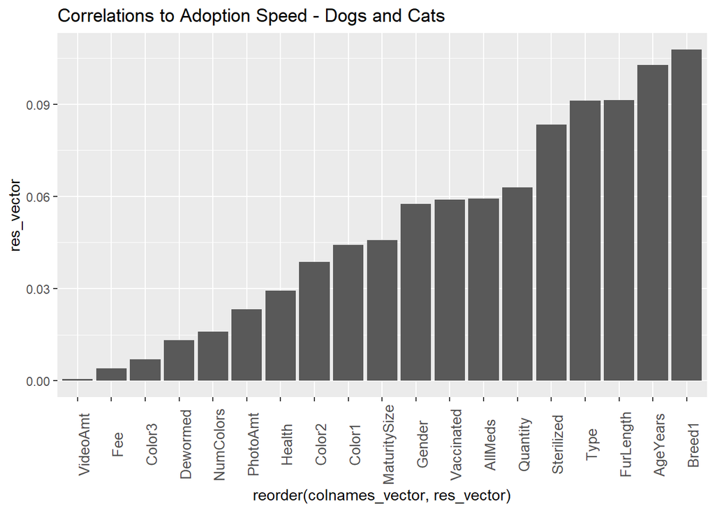

```r
#Dogs and Cats: each feature's correlation to AdoptionSpeed
corrdf_sort = correlations(data)

ggplot(corrdf_sort, aes(x=reorder(colnames_vector,res_vector), y=res_vector)) +
  geom_bar(stat="identity") + ggtitle("Correlations to Adoption Speed - Dogs and Cats") +
  theme(axis.text.x = element_text(angle = 90, size = 10))
```

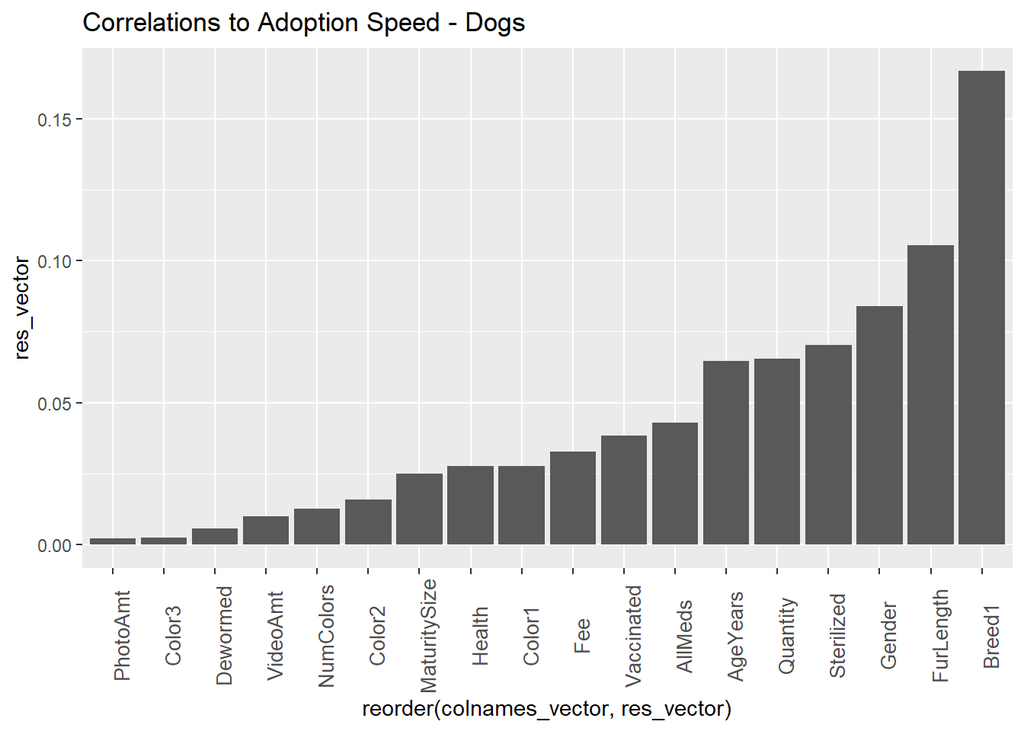

```r
#Dogs: each feature's correlation to AdoptionSpeed
dog_data = filter(data, Type == 1)
dog_data = subset(dog_data, select = -c(Type))
corrdf_sort = correlations(dog_data)

#Dogs: each feature's correlation to AdoptionSpeed
ggplot(corrdf_sort, aes(x=reorder(colnames_vector,res_vector), y=res_vector)) +
  geom_bar(stat="identity") + ggtitle("Correlations to Adoption Speed - Dogs") +
  theme(axis.text.x = element_text(angle = 90, size = 10))
```

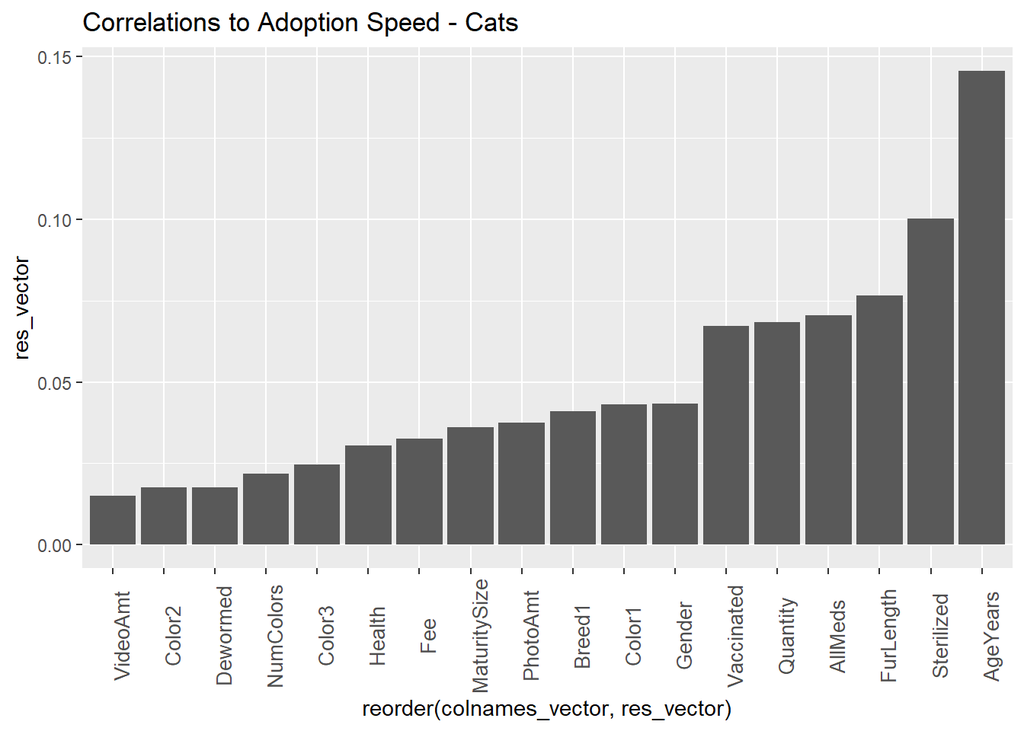

```r
#Cats: each feature's correlation to AdoptionSpeed
cat_data = filter(data, Type == 2)
cat_data = subset(cat_data, select = -c(Type))
corrdf_sort = correlations(cat_data)

#Dogs: each feature's correlation to AdoptionSpeed
ggplot(corrdf_sort, aes(x=reorder(colnames_vector,res_vector), y=res_vector)) +
  geom_bar(stat="identity") + ggtitle("Correlations to Adoption Speed - Cats") +
  theme(axis.text.x = element_text(angle = 90, size = 10))
```

### Visual Correlation between features

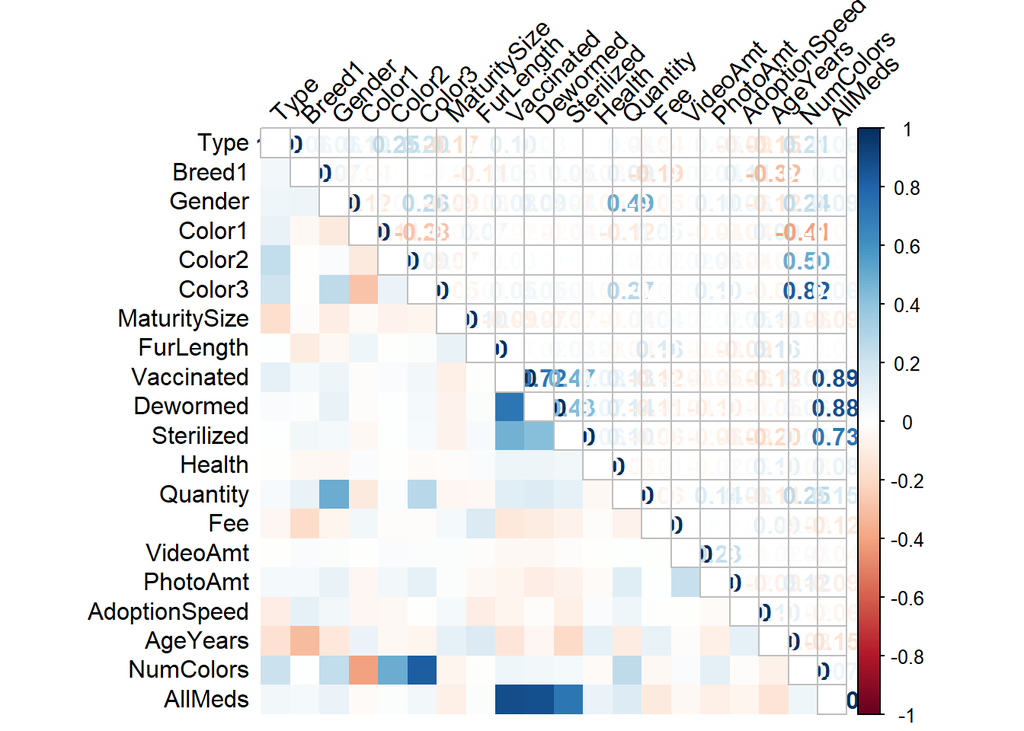

```r
corrplot.mixed(cor(data %>% keep(is.numeric)), tl.col = 'black', tl.pos = 'lt', upper = "number", lower="shade", shade.col=NA, tl.srt=45)
```

### Boxplot of each feature against AdoptionSpeed

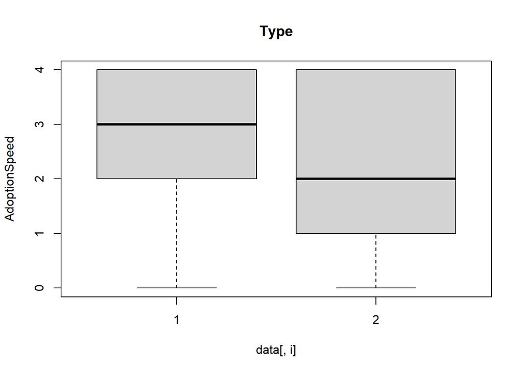

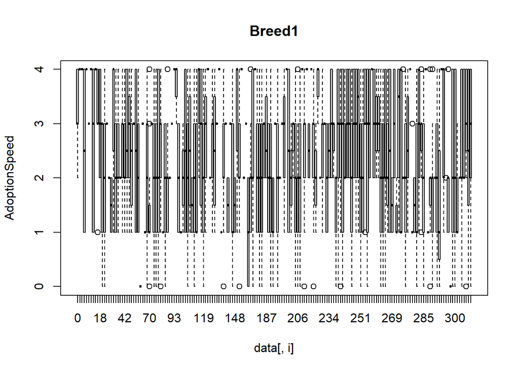

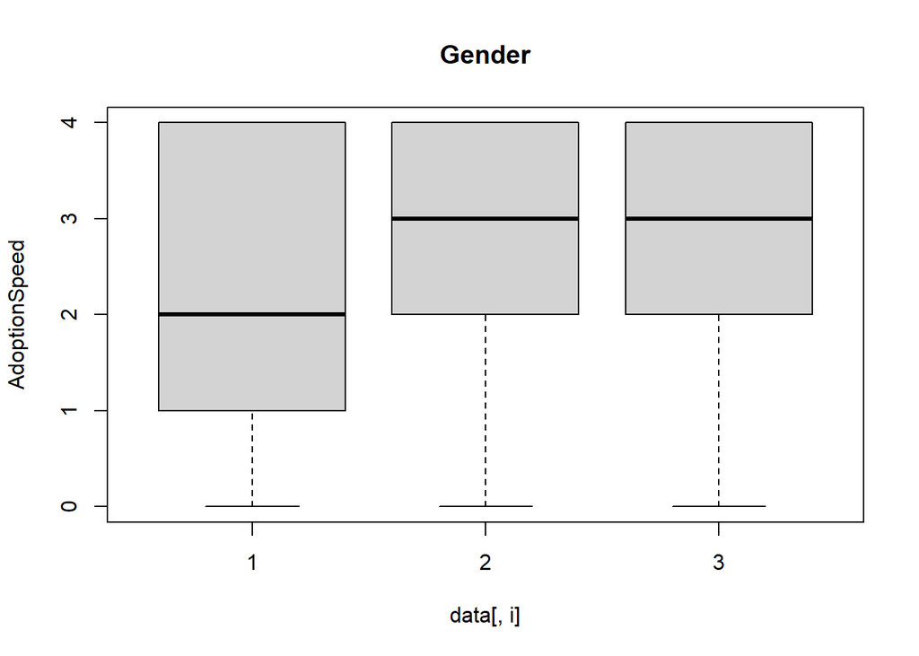

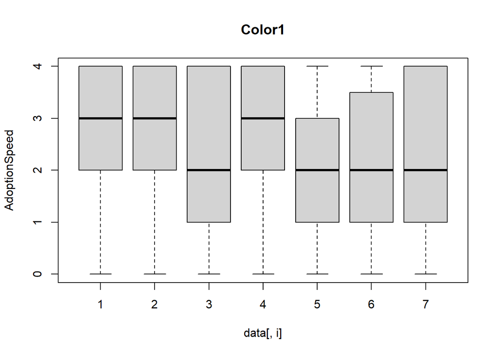

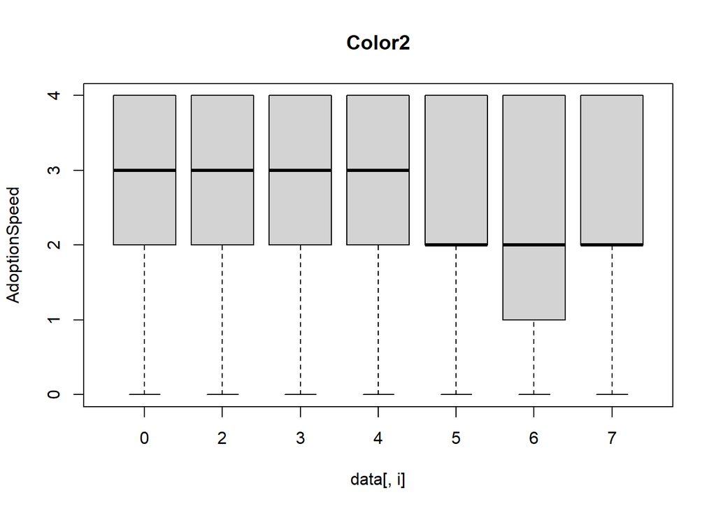

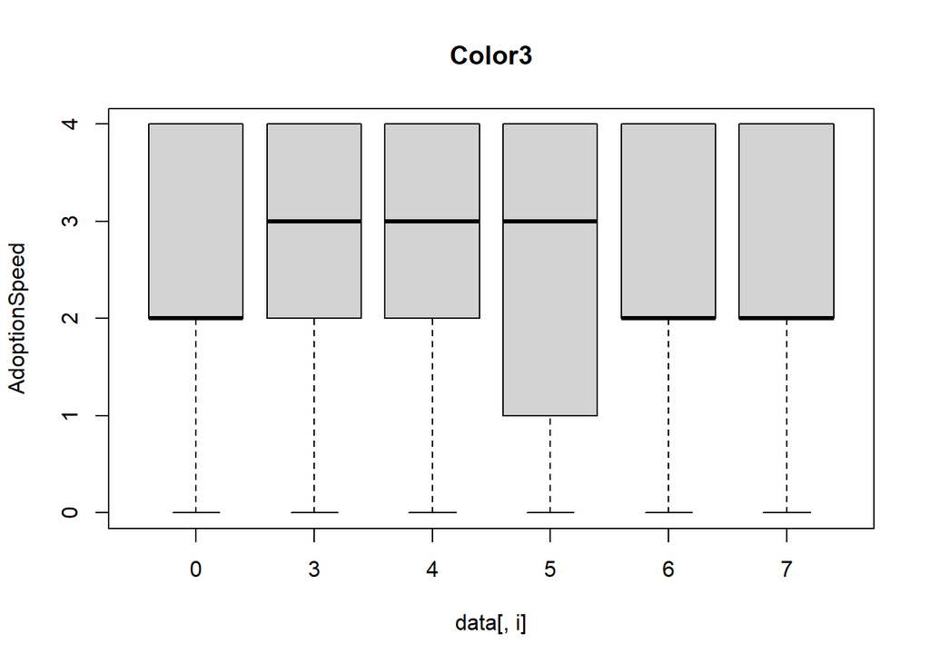

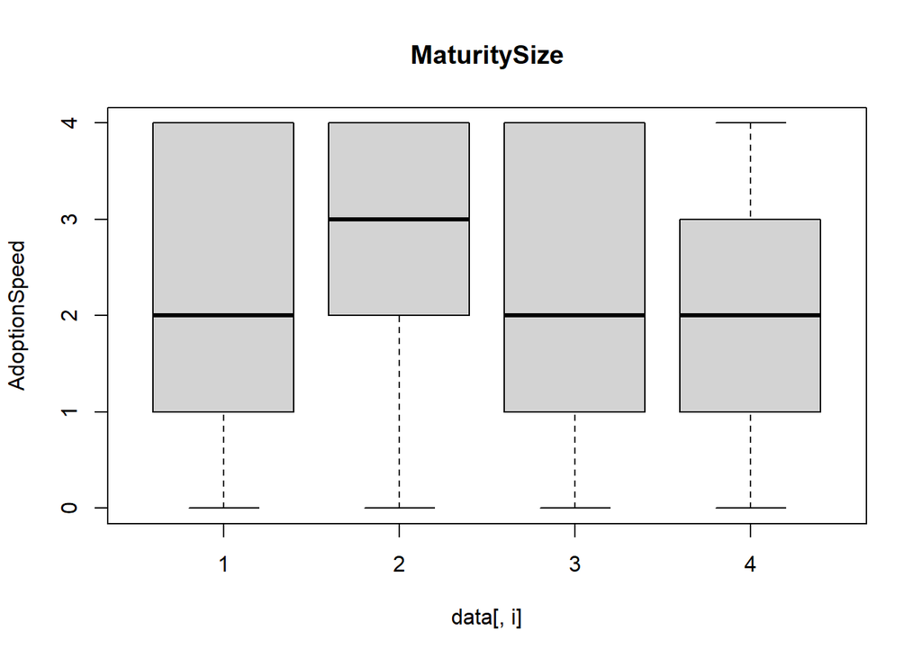

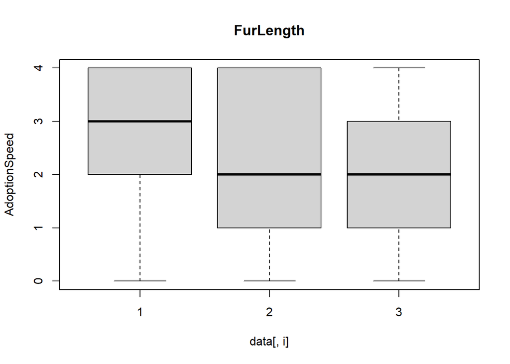

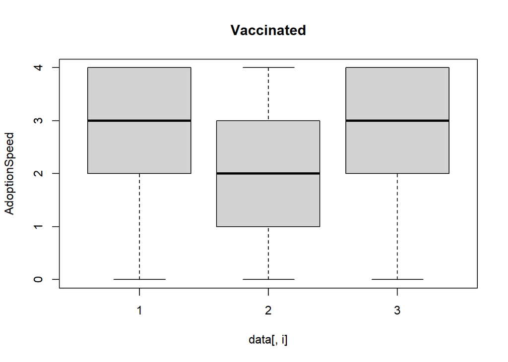

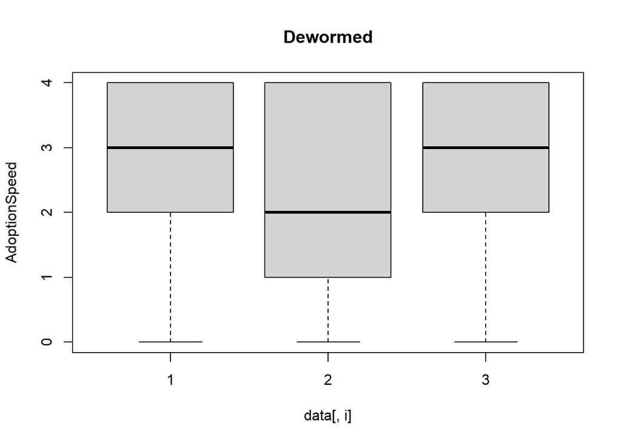

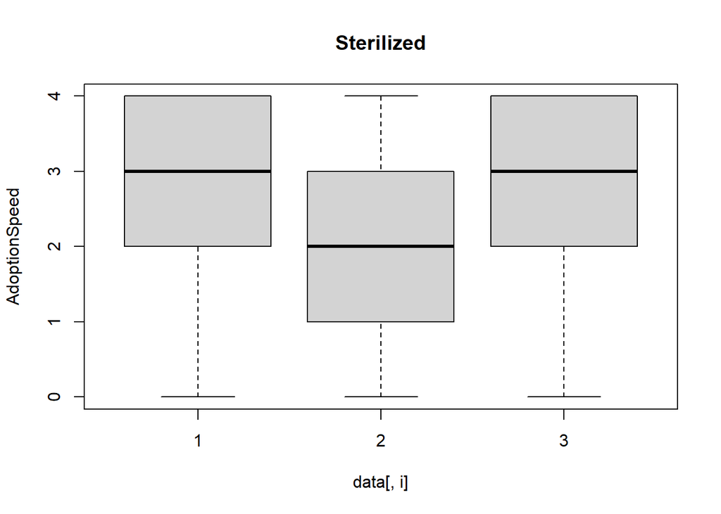

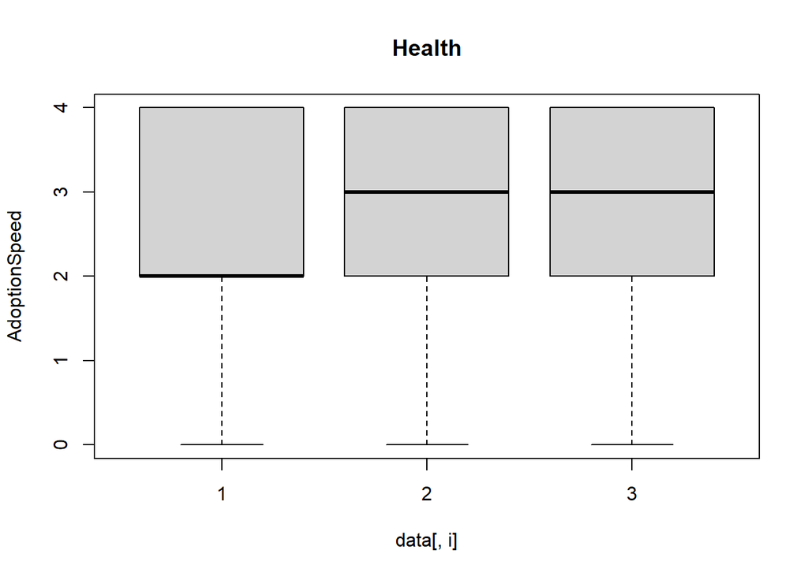

[8 more figures not shown]

```r
column_names = names(data)
for(i in 1:ncol(data)) {
  #ggplot(data, aes(data[ , i], data$AdoptionSpeed)) + geom_bar()
  boxplot(AdoptionSpeed ~ data[ , i], data = data, main=column_names[i])
}
```

### Barplots of each feature’s value counts

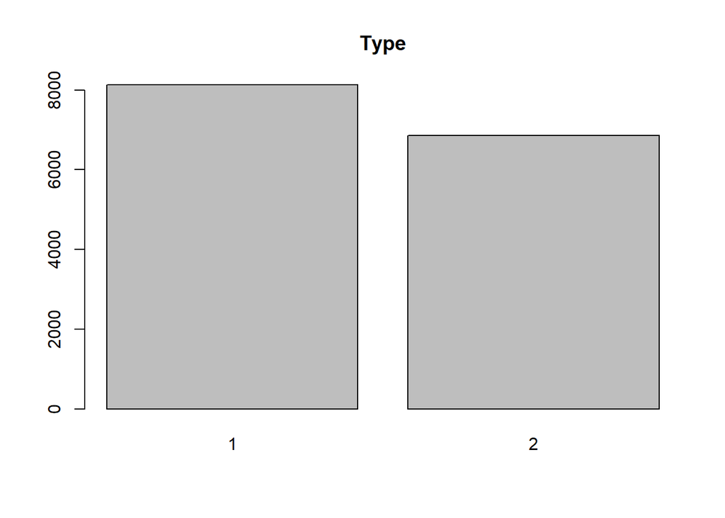

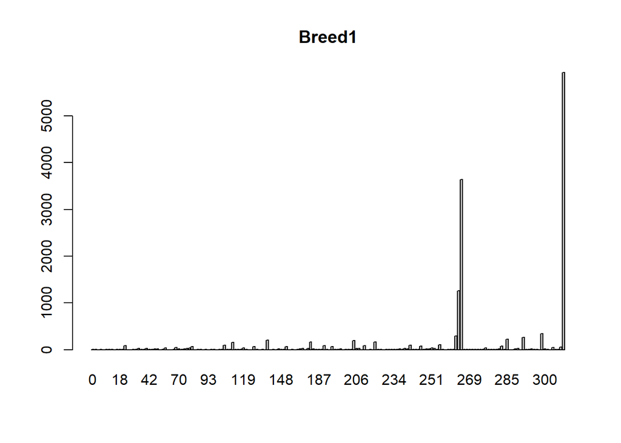

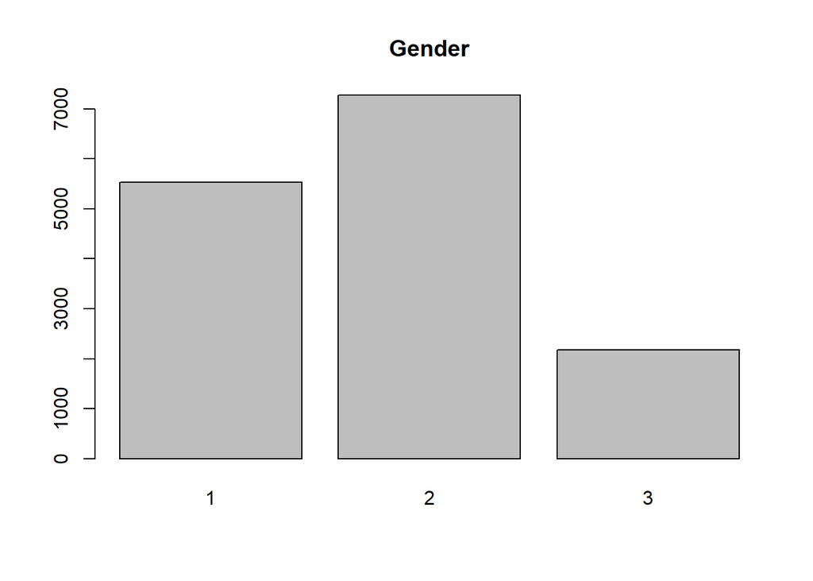

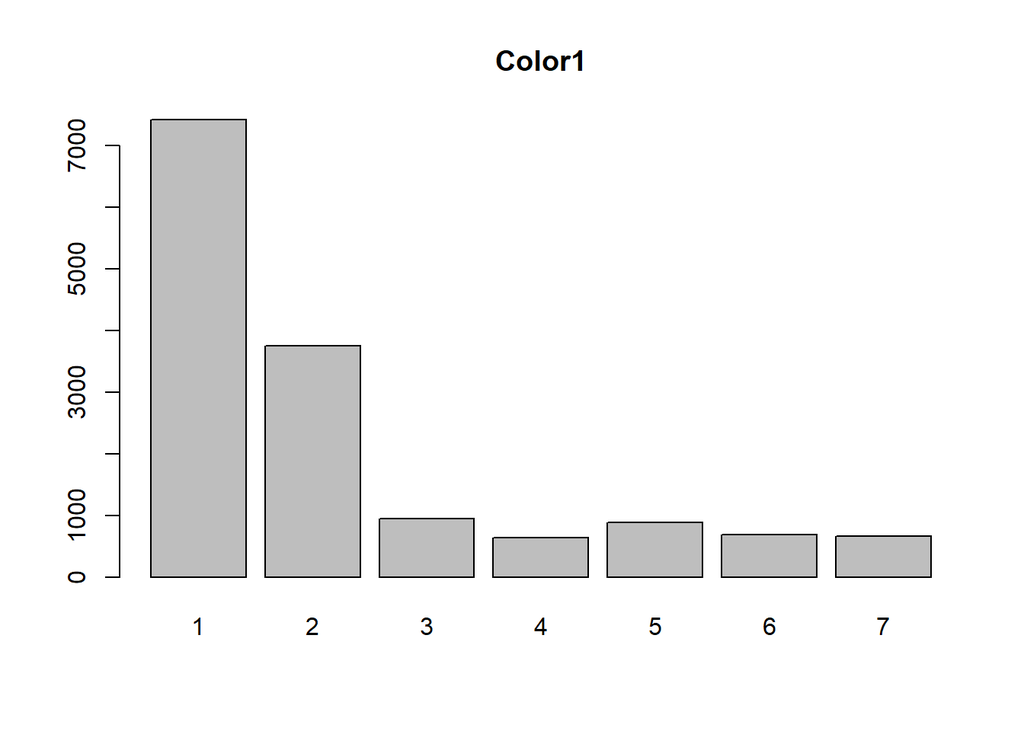

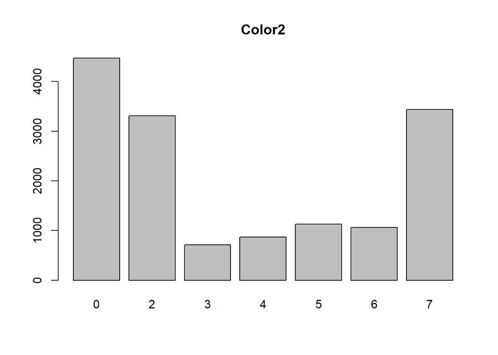

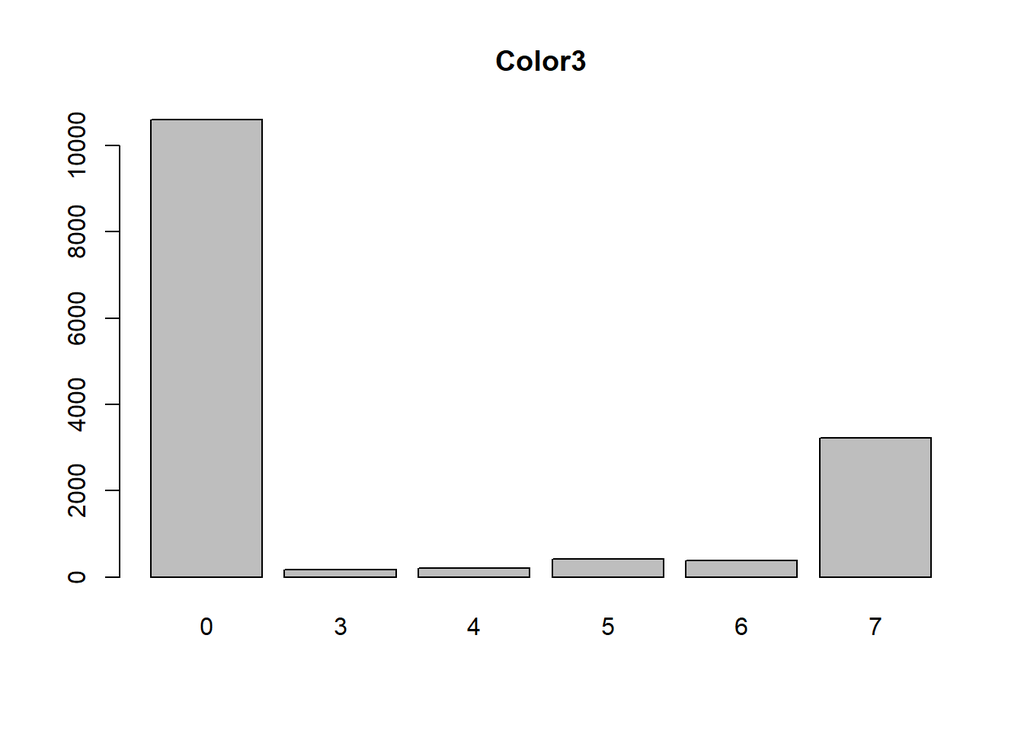

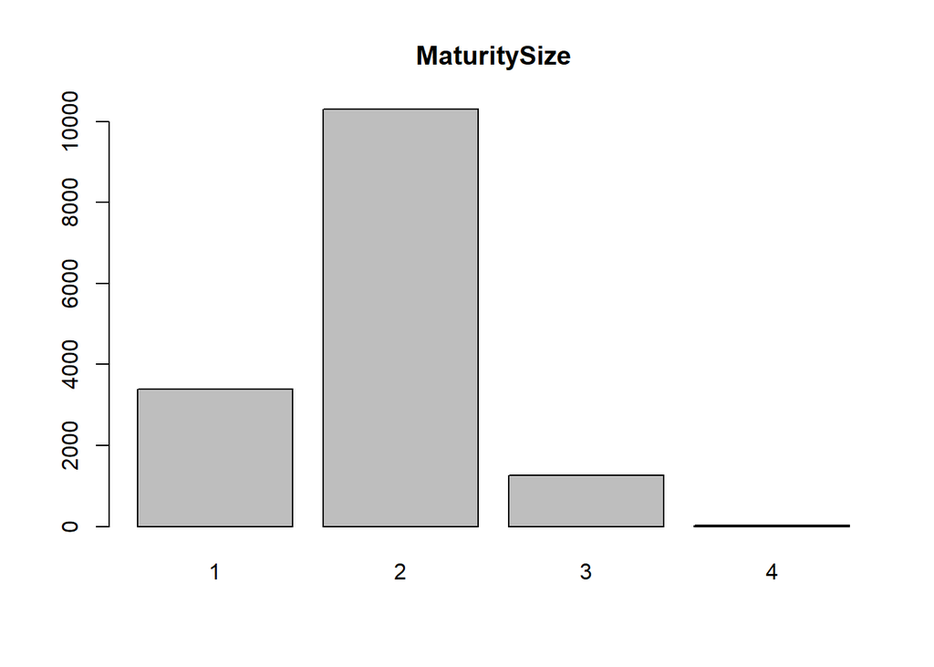

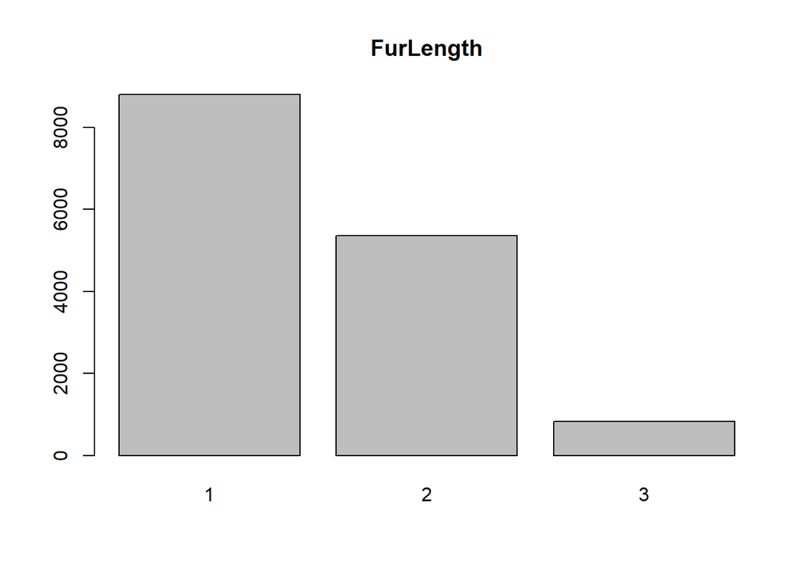

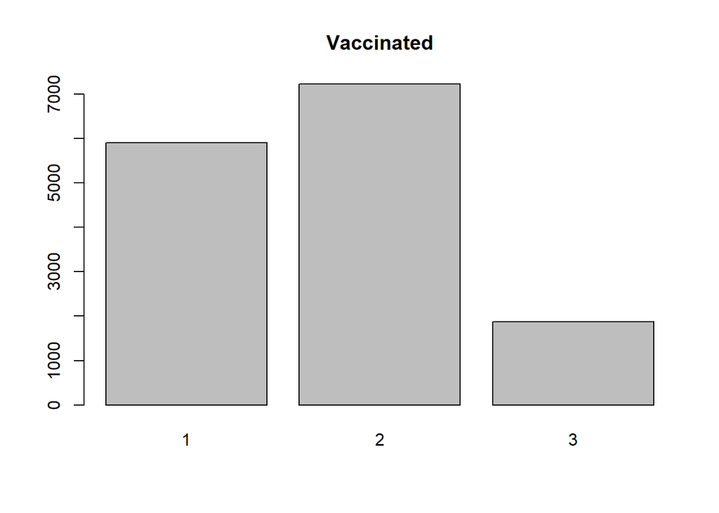

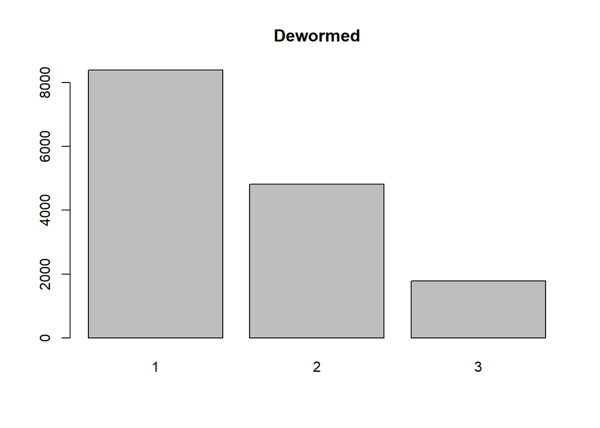

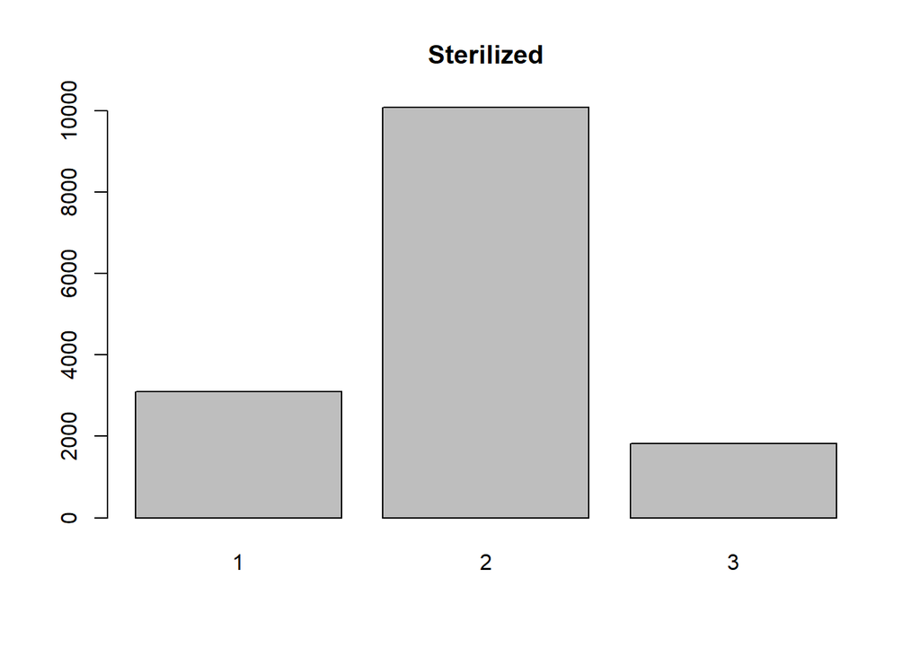

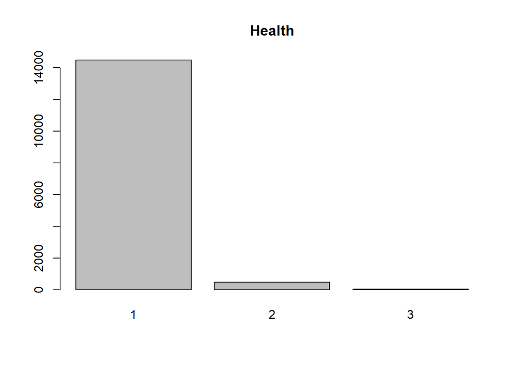

[8 more figures not shown]

```r
for(i in 1:ncol(data)) {
  counts <- table(data[ , i])
  barplot(counts, main=column_names[i])
}
```